# DSCC462_FinalProject

Team6

2022-12-16

```r
data<-read.csv("ads6.csv")
data
```

```
##     socialmedia age   mobile season newcustomer adcost adrevenue
## 1       YouTube  18 computer summer          no  11.97     55.82
## 2     Instagram  31   mobile   fall          no   5.34      9.40
## 3      Facebook  24   mobile spring         yes   6.65      5.22
## 4     Instagram  29   mobile summer         yes   5.43      7.66
## 5       YouTube  32 computer summer          no  11.82      4.61
## 6      Facebook  35   mobile   fall          no   6.61      1.46
## 7        TikTok  21   mobile summer          no   0.21      6.52
## 8        TikTok  16   mobile   fall          no   7.75     13.38
## 9        TikTok  18   mobile spring         yes   7.12      4.69
## 10      YouTube  26 computer spring         yes  13.34     10.17
## 11      YouTube  21   mobile spring          no  14.93     17.90
## 12    Instagram  25   mobile summer         yes   7.05      1.92
## 13    Instagram  31   mobile spring          no   7.39     19.75
## 14     Facebook  20 computer winter          no   4.38      5.39
```

[output cut: 396 more lines]

Q1.(a)

```r
#1a
#library(ggplot2)  # Loads the ggplot2 library
table(data$socialmedia)/length(data$socialmedia)
```

```
##
##   Facebook  Instagram     TikTok    Twitter    YouTube
## 0.13902439 0.20731707 0.31951220 0.04390244 0.29024390
```

```r
#highest tiktok, lowest twitter

data_fb <- subset(data,socialmedia=="Facebook" , select=c("socialmedia","age","mobile","season","newcustomer","adcost","adrevenue"))
fb=nrow(data_fb['age'])


data_twitter <- subset(data,socialmedia=="Twitter" , select=c("socialmedia","age","mobile","season","newcustomer","adcost","adrevenue"))
twitter=nrow(data_twitter)

data_tt <- subset(data,socialmedia=="TikTok" , select=c("age","mobile","season","newcustomer","adcost","adrevenue"))
tt=nrow(data_tt)

data_yt <- subset(data,socialmedia=="YouTube" , select=c("age","mobile","season","newcustomer","adcost","adrevenue"))
yt=nrow(data_yt)


data_insta <- subset(data,socialmedia=="Instagram" , select=c("age","mobile","season","newcustomer"))
insta=nrow(data_insta)


df <- data.frame (first_column  = c('fb','twitter','insta','tiktok','youtube'),
                  second_column = c(fb,twitter,insta,tt,yt)
                  )

df
```

```
##   first_column second_column
## 1           fb            57
## 2      twitter            18
## 3        insta            85
## 4       tiktok           131
## 5      youtube           119
```

```r
#ggplot(data=df,aes(x=first_column,y=second_column,fil=first_column)) + geom_bar(stat = 'identity',fill='steelblue') + labs(x="Social Media Platform", y = "Frequency", title = "Frequency Distribution by Social Media platform")
```

TikTok has the maximum amounts of ads with 30% share followed by YouTube, Instagram, FaceBook and Twitter respectively with 29%, 20%, 14%, 4% contribution respectively.

Q1.(b) H0 : Proportion Values: Twitter=0.1, Facebook=0.1, Instagram=0.2, TikTok=0.3, YouTube=0.3 H1 - Atleast one of these proportions does not hold

```r
#1b
chisq.test(c(18,57,85,131,119),p=c(0.1,0.1,0.2,0.3,0.3))
```

```
##
##  Chi-squared test for given probabilities
##
## data:  c(18, 57, 85, 131, 119)
## X-squared = 19.907, df = 4, p-value = 0.0005211
```

We can see that p value < alpha. We reject the Null Hypothesis. Which means the department is not following the strategy mentioned.

Q1.(c)

```r
#1c
library(e1071)
data_fb
```

```
##     socialmedia age   mobile season newcustomer adcost adrevenue
## 3      Facebook  24   mobile spring         yes   6.65      5.22
## 6      Facebook  35   mobile   fall          no   6.61      1.46
## 14     Facebook  20 computer winter          no   4.38      5.39
## 22     Facebook  25   mobile summer          no   4.52      8.90
## 27     Facebook  22   mobile summer          no   5.88      7.40
## 49     Facebook  24   mobile   fall          no   6.26     18.90
## 53     Facebook  35 computer   fall          no   5.58      3.98
## 80     Facebook  31 computer   fall          no   3.21      3.46
## 83     Facebook  31   mobile   fall          no   3.17      3.39
## 91     Facebook  32 computer summer         yes   4.90      3.93
## 94     Facebook  47   mobile winter          no   6.56     15.65
## 103    Facebook  30   mobile   fall          no   3.52      5.47
## 106    Facebook  33   mobile   fall          no   4.75      2.61
## 107    Facebook  26   mobile spring          no   5.92     13.66
```

[output cut: 43 more lines]

```r
var_fb=var(data_fb$age)
paste("Variance - Facebook :",var_fb)
```

```
## [1] "Variance - Facebook : 69.0889724310777"
```

```r
std_fb=sd(data_fb$age)
paste("Standard Deviation - Facebook :",std_fb)
```

```
## [1] "Standard Deviation - Facebook : 8.31197764861514"
```

```r
coeff_var_fb=std_fb/mean(data_fb$age)
paste("Coefficient of Variation - Facebook :",coeff_var_fb)
```

```
## [1] "Coefficient of Variation - Facebook : 0.259891786051049"
```

```r
skew_fb=skewness(data_fb$age)
paste("Skew - Facebook :",skew_fb)
```

```
## [1] "Skew - Facebook : 0.471956577500652"
```

```r
mean(data_fb$age)
```

```
## [1] 31.98246
```

```r
median(data_fb$age)
```

```
## [1] 31
```

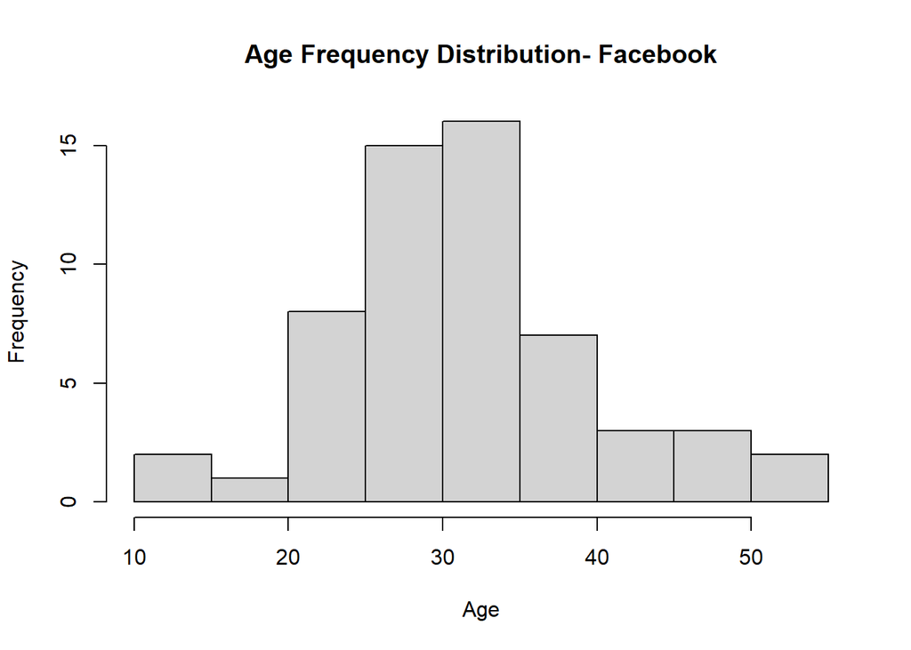

```r
hist(data_fb$age, xlab="Age", main = "Age Frequency Distribution- Facebook")
```

```r
min(data_fb$age)
```

```
## [1] 14
```

```r
data_twitter
```

```
##     socialmedia age   mobile season newcustomer adcost adrevenue
## 75      Twitter  38   mobile   fall          no   3.95     12.57
## 86      Twitter  30   mobile   fall          no   3.19      8.19
## 100     Twitter  25   mobile winter         yes   1.67     14.62
## 111     Twitter  31 computer spring          no   2.04      2.20
## 126     Twitter  35 computer winter         yes   1.35      8.65
## 134     Twitter  45   mobile spring          no   3.00      3.43
## 138     Twitter  35 computer spring          no   2.94     15.94
## 173     Twitter  41   mobile winter          no   1.72      3.89
## 242     Twitter  35 computer winter          no   1.92     12.34
## 281     Twitter  36 computer   fall          no   2.77      1.92
## 289     Twitter  35   mobile winter          no   2.60      1.45
## 322     Twitter  31 computer spring          no   2.44      5.49
## 334     Twitter  36   mobile summer         yes   3.84      3.28
## 341     Twitter  38   mobile summer         yes   2.85      5.84
## 370     Twitter  26   mobile   fall          no   1.38      1.17
## 378     Twitter  44 computer winter         yes   1.61     10.27
## 380     Twitter  40 computer winter          no   2.49      1.43
## 409     Twitter  45   mobile   fall          no   3.99     16.01
```

```r
var_twitter=var(data_twitter$age)
paste("Variance - Twitter :",var_twitter)
```

```
## [1] "Variance - Twitter : 34.4575163398693"
```

```r
std_twitter=sd(data_twitter$age)
paste("Standard Deviation - Twitter :",std_twitter)
```

```
## [1] "Standard Deviation - Twitter : 5.87005249890231"
```

```r
coeff_var_twitter=std_twitter/mean(data_twitter$age)
paste("Coefficient of Variation - Twitter :",coeff_var_twitter)
```

```
## [1] "Coefficient of Variation - Twitter : 0.163561834334739"
```

```r
skew_twitter=skewness(data_twitter$age)
paste("Skew - Twitter :",skew_twitter)
```

```
## [1] "Skew - Twitter : -0.118302138027647"
```

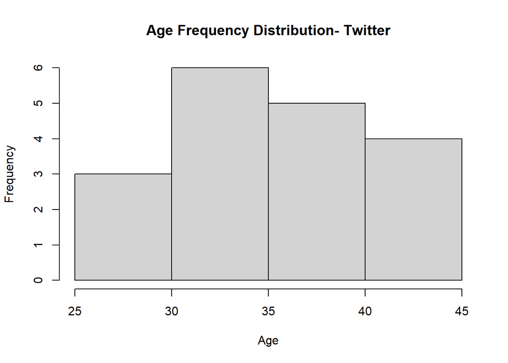

```r
hist(data_twitter$age, xlab="Age", main = "Age Frequency Distribution- Twitter")
```

```r
data_insta
```

```
##     age   mobile season newcustomer
## 2    31   mobile   fall          no
## 4    29   mobile summer         yes
## 12   25   mobile summer         yes
## 13   31   mobile spring          no
## 23   30 computer   fall         yes
## 28   30   mobile winter         yes
## 29   25   mobile spring          no
## 39   23   mobile winter          no
## 41   28   mobile spring          no
## 44   22   mobile   fall          no
## 47   19   mobile winter         yes
## 56   26   mobile spring          no
## 57   28   mobile summer          no
## 66   26   mobile   fall          no
```

[output cut: 71 more lines]

```r
var_insta=var(data_insta$age)
paste("Variance - Instagram :",var_insta)
```

```
## [1] "Variance - Instagram : 17.7193277310924"
```

```r
std_insta=sd(data_insta$age)
paste("Standard Deviation - Instagram :",std_insta)
```

```
## [1] "Standard Deviation - Instagram : 4.2094331840632"
```

```r
coeff_var_insta=std_insta/mean(data_insta$age)
paste("Coefficient of Variation - Instagram :",coeff_var_insta)
```

```
## [1] "Coefficient of Variation - Instagram : 0.157760943847166"
```

```r
skew_insta=skewness(data_insta$age)
paste("Skew - Instagram :",skew_insta)
```

```
## [1] "Skew - Instagram : -0.112286241794097"
```

```r
mean(data_insta$age)
```

```
## [1] 26.68235
```

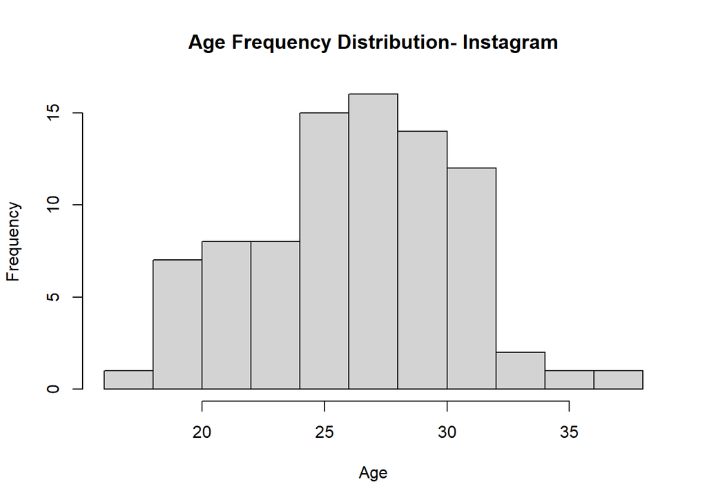

```r
hist(data_insta$age, xlab="Age", main = "Age Frequency Distribution- Instagram")
```

```r
data_tt
```

```
##     age   mobile season newcustomer adcost adrevenue
## 7    21   mobile summer          no   0.21      6.52
## 8    16   mobile   fall          no   7.75     13.38
## 9    18   mobile spring         yes   7.12      4.69
## 17   17   mobile summer         yes   0.80      0.80
## 18   15   mobile   fall          no   0.68      1.29
## 20   17   mobile summer          no   1.99      1.88
## 21   19   mobile winter         yes   6.97     14.64
## 24   17   mobile winter          no   3.24      1.80
## 25   21   mobile spring          no   6.74     11.26
## 26   27   mobile winter         yes   7.12      5.19
## 31   22   mobile   fall          no   3.85     16.06
## 32   15   mobile summer          no   4.35     19.55
## 42   24 computer summer         yes   5.30      6.57
## 48   23   mobile summer         yes   3.74      8.53
```

[output cut: 117 more lines]

```r
var_tt=var(data_tt$age)
paste("Variance - TikTok :",var_tt)
```

```
## [1] "Variance - TikTok : 9.66858485026424"
```

```r
std_tt=sd(data_tt$age)
paste("Standard Deviation - TikTok :",std_tt)
```

```
## [1] "Standard Deviation - TikTok : 3.10943481203003"
```

```r
coeff_var_tt=std_tt/mean(data_tt$age)
paste("Coefficient of Variation - TikTok :",coeff_var_tt)
```

```
## [1] "Coefficient of Variation - TikTok : 0.169159451983361"
```

```r
skew_tt=skewness(data_tt$age)
paste("Skew - TikTok :",skew_tt)
```

```
## [1] "Skew - TikTok : 0.0994066020243992"
```

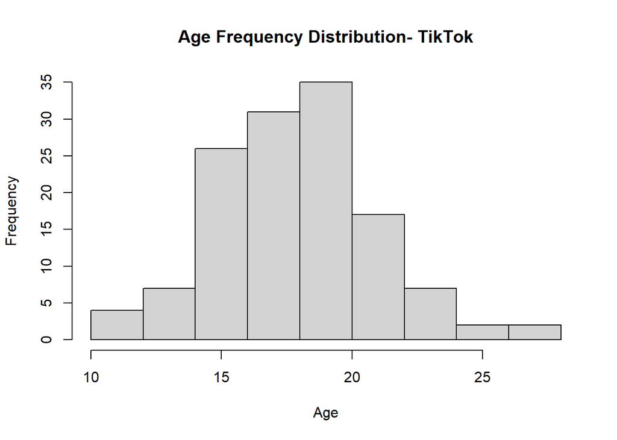

```r
hist(data_tt$age, xlab="Age", main = "Age Frequency Distribution- TikTok")
```

```r
data_yt
```

```
##     age   mobile season newcustomer adcost adrevenue
## 1    18 computer summer          no  11.97     55.82
## 5    32 computer summer          no  11.82      4.61
## 10   26 computer spring         yes  13.34     10.17
## 11   21   mobile spring          no  14.93     17.90
## 15   30 computer   fall         yes  11.12     45.30
## 16   34 computer   fall          no  11.31     65.50
## 19   35 computer   fall         yes  12.96     29.14
## 30   48 computer   fall          no  12.40     52.73
## 33   40 computer   fall         yes  10.88     15.52
## 34   29 computer spring          no   7.26     13.01
## 35   17 computer summer          no   9.50      3.14
## 36   42 computer spring          no  10.21     56.18
## 37   37 computer spring          no  14.81     64.23
## 38   37 computer summer         yes  14.49     25.50
```

[output cut: 105 more lines]

```r
var_yt=var(data_yt$age)
paste("Variance - YouTube :",var_yt)
```

```
## [1] "Variance - YouTube : 96.4912405640222"
```

```r
std_yt=sd(data_yt$age)
paste("Standard Deviation - YouTube :",std_yt)
```

```
## [1] "Standard Deviation - YouTube : 9.82299549852397"
```

```r
coeff_var_yt=std_yt/mean(data_yt$age)
paste("Coefficient of Variation - YouTube :",coeff_var_yt)
```

```
## [1] "Coefficient of Variation - YouTube : 0.30850790824079"
```

```r
skew_yt=skewness(data_yt$age)
paste("Skew - YouTube :",skew_yt)
```

```
## [1] "Skew - YouTube : -0.118472214968922"
```

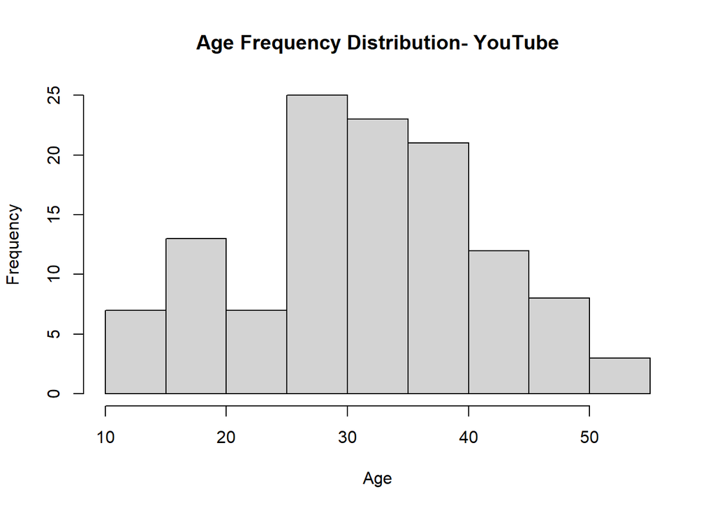

```r
hist(data_yt$age, xlab="Age", main = "Age Frequency Distribution- YouTube")
```

Age is normally distributed across all social media platforms except for twitter in which the we have very less amount of data.

Q2.(a)

```r
library(ggplot2)
#2a


data$profit=data$adrevenue-data$adcost
print(data)
```

```
##     socialmedia age   mobile season newcustomer adcost adrevenue profit
## 1       YouTube  18 computer summer          no  11.97     55.82  43.85
## 2     Instagram  31   mobile   fall          no   5.34      9.40   4.06
## 3      Facebook  24   mobile spring         yes   6.65      5.22  -1.43
## 4     Instagram  29   mobile summer         yes   5.43      7.66   2.23
## 5       YouTube  32 computer summer          no  11.82      4.61  -7.21
## 6      Facebook  35   mobile   fall          no   6.61      1.46  -5.15
## 7        TikTok  21   mobile summer          no   0.21      6.52   6.31
## 8        TikTok  16   mobile   fall          no   7.75     13.38   5.63
## 9        TikTok  18   mobile spring         yes   7.12      4.69  -2.43
## 10      YouTube  26 computer spring         yes  13.34     10.17  -3.17
## 11      YouTube  21   mobile spring          no  14.93     17.90   2.97
## 12    Instagram  25   mobile summer         yes   7.05      1.92  -5.13
## 13    Instagram  31   mobile spring          no   7.39     19.75  12.36
## 14     Facebook  20 computer winter          no   4.38      5.39   1.01
```

[output cut: 396 more lines]

```r
max(data$profit)
```

```
## [1] 81.73
```

```r
data_winter <- subset(data,season=="winter" , select=c("age","mobile","season","newcustomer","adcost","adrevenue","profit"))
data_winter
```

```
##     age   mobile season newcustomer adcost adrevenue profit
## 14   20 computer winter          no   4.38      5.39   1.01
## 21   19   mobile winter         yes   6.97     14.64   7.67
## 24   17   mobile winter          no   3.24      1.80  -1.44
## 26   27   mobile winter         yes   7.12      5.19  -1.93
## 28   30   mobile winter         yes   6.83      3.01  -3.82
## 39   23   mobile winter          no   6.96      2.13  -4.83
## 47   19   mobile winter         yes   6.92     20.34  13.42
## 59   18   mobile winter         yes   4.30      7.06   2.76
## 60   19   mobile winter         yes   6.46      6.28  -0.18
## 62   19   mobile winter         yes   1.68      9.96   8.28
## 67   29 computer winter          no  13.65     14.86   1.21
## 70   16 computer winter         yes   7.92      3.89  -4.03
## 71   22   mobile winter         yes   1.79      4.09   2.30
## 72   30   mobile winter          no   4.11      3.96  -0.15
```

[output cut: 88 more lines]

```r
data_spring <- subset(data,season=="spring" , select=c("age","mobile","season","newcustomer","adcost","adrevenue","profit"))
data_fall <- subset(data,season=="fall" , select=c("age","mobile","season","newcustomer","adcost","adrevenue","profit"))
data_summer <- subset(data,season=="summer" , select=c("age","mobile","season","newcustomer","adcost","adrevenue","profit"))
data_summer
```

```
##     age   mobile season newcustomer adcost adrevenue profit
## 1    18 computer summer          no  11.97     55.82  43.85
## 4    29   mobile summer         yes   5.43      7.66   2.23
## 5    32 computer summer          no  11.82      4.61  -7.21
## 7    21   mobile summer          no   0.21      6.52   6.31
## 12   25   mobile summer         yes   7.05      1.92  -5.13
## 17   17   mobile summer         yes   0.80      0.80   0.00
## 20   17   mobile summer          no   1.99      1.88  -0.11
## 22   25   mobile summer          no   4.52      8.90   4.38
## 27   22   mobile summer          no   5.88      7.40   1.52
## 32   15   mobile summer          no   4.35     19.55  15.20
## 35   17 computer summer          no   9.50      3.14  -6.36
## 38   37 computer summer         yes  14.49     25.50  11.01
## 42   24 computer summer         yes   5.30      6.57   1.27
## 43   20 computer summer         yes   5.87     11.27   5.40
```

[output cut: 81 more lines]

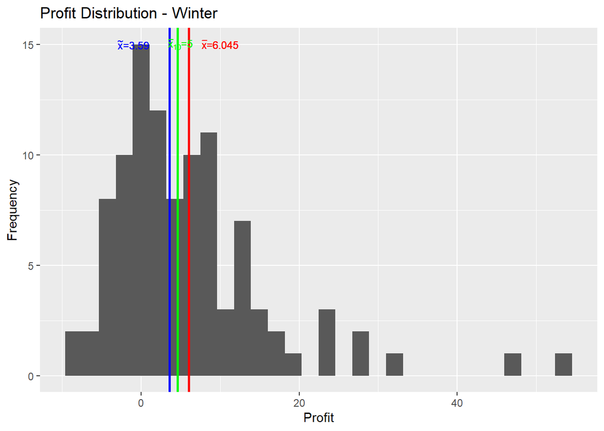

```r
x<-ggplot(data_winter, aes(x=profit)) + geom_histogram()
x<- x + geom_vline(aes(xintercept=mean(data_winter$profit)),linewidth=1,color="red") + geom_vline(aes(xintercept=median(data_winter$profit)),linewidth=1,color="blue") + geom_vline(aes(xintercept=mean(data_winter$profit,trim=0.1)),linewidth=1,color="green")
x <- x + annotate("text",x=10, y=15, label = substitute(paste(bar(x),"=",m), list(m=round(mean(data_winter$profit),3))), color = "red", size = 3) + annotate("text",x=-1, y=15, label = substitute(paste(tilde(x),"=",m), list(m=round(median(data_winter$profit),3))), color = "blue", size = 3)+
  annotate("text",x=5, y=15, label = substitute(paste(bar(x)[10],"=",m), list(m=round(mean(data_winter$profit,trim=0.1)))), color = "green", size = 3)
x <- x + labs(x="Profit", y="Frequency",title="Profit Distribution - Winter")
x
```